# Braki odpowiedzi w wybranych badaniach reprezentacyjnych gospodarstw domowych

## BAEL, BBGD, EU-SILC, ICT

Sebastian Kuzara & Maciej Beręsewicz

## Agenda

1. Braki odpowiedzi w badaniach reprezentacyjnych - skutki, definicja, rodzaje
2. Przyczyny braków odpowiedzi
3. Schematy losowania i organizacji badań reprezentacyjnych - porównanie
4. Wskaźnik realizacji w badaniach reprezentacyjnych (ogólnie i w przekrojach)
5. Przykłady - prezentacja na wykresach danych dotyczących braków odpowiedzi/wskaźników realizacji w wybranych przekrojach
6. Podsumowanie i rekomendacje

## Błędy w badaniach reprezentacyjnych

- **Błędy losowe** - związane z precyzją wyników w próbie
- **Błędy nielosowe:**
  - błędy operatu
  - pomiaru (niezrozumiała instrukcja)
  - odpowiedzi (niechęć udzielania prawdziwych odpowiedzi)
  - **błędy spowodowane brakami odpowiedzi**

## Skutki braków odpowiedzi

- Zmniejszenie liczebności próby, co wpływa na zwiększenie wariancji estymatorów
- Braki odpowiedzi, jeżeli występują w dużej liczbie, mogą negatywnie wpływać na jakość wyników
- Struktura próby zbadanej różni się od struktury próby wylosowanej pod względem cech społeczno-demograficznych
- Zwiększenie obciążenia estymatora

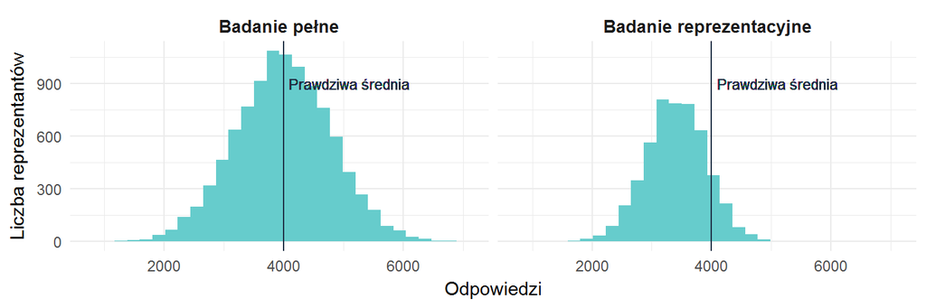

## Definicja

**Brak odpowiedzi** - sytuacja, w której, pomimo próby kontaktu ze strony ankietera, nie jest możliwe uzyskanie od respondenta informacji na pytania zawarte w ankiecie niezależnie od przyczyny, pod warunkiem że wylosowane do próby mieszkanie istnieje, pełni funkcje mieszkaniowe, jest zamieszkałe przez rospendentów spełniających założone w badaniu kryteria lub istnieje takie podejrzenie*.

*Definicja własna na podstawie raportów z badań BGD, AEL, EU-SILC, ICT oraz *Standard Definitions…*

## Rodzaje braków odpowiedzi

- **Całkowity** brak odpowiedzi
- **Częściowy** brak odpowiedzi

## Rodzaje braków odpowiedzi w BBGD i EU-SILC

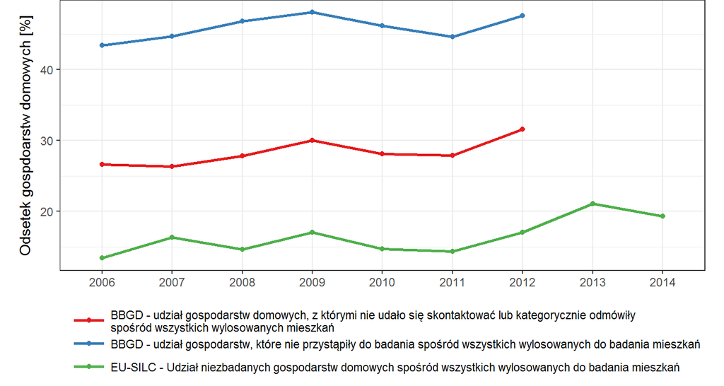

## Z czego wynikają braki odpowiedzi?

- **Przyczyny obiektywne:**
  - Utrudniony kontakt np. z powodu choroby
  - Czasowa nieobecność
  - Brak dostępu do mieszkania
  - Rozpad gospodarstwa domowego
  - Nikogo nie zastano w mieszkaniu
- **Przyczyny subiektywne:**
  - Odmowa udzielenia odpowiedzi
  - Niechęć
  - Brak czasu

## Przyczyny braków odpowiedzi w BBGD i EU-SILC

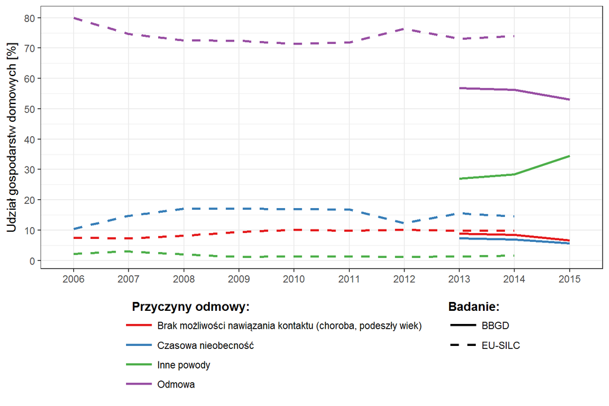

## Kategorie przyczyn niepodjęcia udziału w badaniu

| EU.SILC | BBGD |
| --- | --- |
| odmowa | odmowa |
| utrudnony kontakt | utrudnony kontakt |
| czasowa nieobecność | czasowa nieobecność |
| inne | inne |
|  | nikogo nie zastano |
|  | brak dostępu do mieszkania |
|  | rozpad gospodarstwa domowego |

## Badania

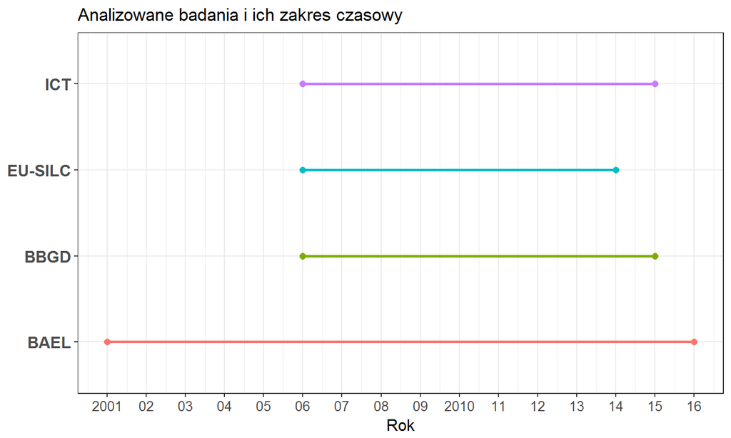

Schematy losowania - porównanie

Wyszczególnienie

BBGD

EU.SILC

BAEL

ICT

moteda losowania

losowanie dwustopniowe z warstwaniem na pierwszym stopniu

losowanie dwustopniowe z warstwaniem na pierwszym stopniu

losowanie dwustopniowe z warstwaniem na pierwszym stopniu

losowanie dwustopniowe z warstwaniem na pierwszym stopniu

jednostka pierwszego stopnia

rejony statystyczne* według spisów przygotowanych na potrzeby NSP z późniejszymi rocznymi aktualizacjami**

* rejon statystyczny w miastach liczy około 250 mieszkań a na terenech wiejskich około 150

** łącznie około 30 tys. JPS

obwody spisowe

miasta: rejony statystyczne

tereny wiejskie: obwody spisowe

obwody spisowe>rejony statystyczne

- występują (rzadko) sytuacje łączenia kilku rejonów/obowdów w jeden JPS

rejony statystyczne według danych utworzonych na rzecz NSP miasta: 250 mieszkań tereny wiejskie 150 mieszkań

jednostka drugiego stopnia

zamieszkałe mieszkania według wykazów sprządzonych przez urzędy statystyczne

zamieszkałe mieszkania z listy sporządzonej na podstawie TERYT

mieszkania losowane z listy stworzonej na podstawie Krajowego Rejestru Podziału Terytorialnego Kraju (TERYT)

mieszkania

## Warstwowanie JPS

BBGD

EU.SILC

BAEL

ICT

1. województwa
2. 6 klas miejscowości
3. w Warszawie warstwami są dzielnice (łączone)
4. duże miasta tworzą samodzielne warstwy
5. małe miasta i tereny wiejskie według NTS3
- 191 warstw w tym 58 wiejskich
- warstwy terenow wiejskich tworzone z połączenia terenów wiejskich z kilku powiatów
1. województwa
1. klasy miejscowości
2. 5 największych miast - dzielnice
3. duże miasta - samodzielne warstwy
4. tereny wiejskie - gminy wiejskie w podregionie (lub w kilku powiatach)
5. tereny miejskie według wielkości miast
- 211 warstw
1. województwa
1. klasy miejscowości
- od 3 do 7 warstw wewnątrz- wojewódzkich
- brak sztywnego kryterium podziału na warstwy wewnątrz- wojewódzkie
1. województwa
1. klasy miejscowości
2. aglomeracje miejskie - osobne warstwy
- 96 warstw

## Losowanie JPS (1)

BBGD

EU.SILC

BAEL

ICT

1. liczba losowanych JPS proporcjonalna do liczby mieszkań w warstwach
1. liczba losowanych JPS z pojedynczej warstwy równa się liczbie mieszkań do wylosowania z warstwy podzielonej przez liczbie mieszkań dla konkretnej klasy miejscowości
1. Metoda ekspercka ustalania liczby JPS losowanych z warstwy
1. liczba losowanych JPS w warstwie proporcjonalna do liczby mieszkań w warstwie
1. Brak informacji na temat schematu losowania JPS*

* losowanie dodatkowo pewnej liczby JPS wiejskich z puli JPS terenów wiejskich

1. losowanie za pomocą schematu Hartley'a-Rao:
- posortowanie losowo JPS w warstwie
- utworzenie zmiennej ze skumulowaną sumą wartości zmiennej, która ustala prawdopodobieństwo wylosowania JPS
- systematyczny wybór co sum(x)/n jednostki według zmiennej ze skumulowaną sumą
1. prawdopodobieństwo wylosowania JPS z warstwy proporcjonalne do liczby mieszkań w JPS
1. Losowanie wg schematu Hartley'a-Rao (patrz EU-SILC)

## Losowanie JPS (2)

BBGD

EU.SILC

BAEL

ICT

1. Próba dla każdego roku jest dzielona na dwie równe podpróbki. Każda z nich oprócz badanego roku bazowego obejmuje swoim zakresem rok poprzedzający lub rok nastepujący po właściwym roku badania (1)-2-(1)
1. W każdym roku JPS dzielone na 4 podpróby
- każdego roku jedna podpróba jest zastepowana przez nową
1. JPS dzielone są dla każdego kwartału na 4 próby elementarne, a następnie każda próba elementarna dzielona jest na 13 tygodniowych próbek elementarnych
1. Brak dzielenia próby

losowanie 783 JPS (dane dla 2014 r.)

losowanie 1350 JPS

## Losowanie JDS (1)

BBGD

EU.SILC

BAEL

ICT

W każdym JPS losuje się 24 mieszkania. Po 2 mieszkania na miesiąc.

Liczba losowanych mieszkań w JPS zależna od rodzaju warstwy:

1. miasta powyżej 100 tys. mieszkańców: 3 mieszkania
2. miasta 20-100 tys.: 4 mieszkania
3. miasta poniżej 20 tys.: 5 mieszkań
4. tereny wiejskie: 6 mieszkań

Liczba mieszkań losowanych w każdym wojewodztwie proporcjonalna do pierwiasta z liczby mieszkańców w województwie (nadreprezentacja mniejszych województw)

tygodniowa próbka składa się z 44-90 mieszkań na województwo

4-11 mieszkań w JPS w zależności od klasy miejscowości warstwy:

- tereny wiejskie i małe miasta: 8-9 mieszkań
- śednie miasta: 6-7 mieszkań
- tereny wielkomiejskie: 6 mieszkań

6 mieszkań w JPS

## Losowanie JDS (2)

BBGD

EU.SILC

BAEL

ICT

1. Losowanie proste - jednakowe prawdopodobieństwo wylosowania każdego mieszkania. Ma to przełożenie na schemat losowania JPS
1. Losowanie proste
1. Losowanie proste (?)
1. Losowanie proste (?)
1. model całkowitej rotacji z miesięcznym okresem wymiany próby. Każde mieszkanie badane jest w dwóch kolejnych latach
1. Mieszkanie jest badane w 4 kolejnych latach (co roku eliminowana jedna podpróba z czterech)
1. 4-krotne badanie jednego mieszkania (badanie w 2 następujących po sobie kwartałach - dwa kwartały przerwy - badanie w 2 następujących po sobie kwartałach)
1. bd
1. 37148 mieszkań (2015 r.)
1. ok 24000 mieszkań
1. 31,3 tys. gospodarstw domowych (w tym 20,5 tys. w miastach) oraz 65 tys. osób (w tym 38,8 tys.w maistach) - dane na 2 kwartału 2016
1. 8100 mieszkań

## Scematy losowania - informacje dodatkowe (1)

Wyszczególnienie

BBGD

EU.SILC

BAEL

ICT

Termin badania

Badanie ciągłe

5.05-18.07 (dla roku 2014)

Badanie ciągłe

Badanie coroczne

Forma badania

1. dwie dwutygodniowe książeczki (nt rozchdoow, przychodow, spożycia itp..)
2. wywiad bezpośredni na koniec miesiąca
3. wywiad kwartalny

wywiad bezpośredni

1. wywiad bezpośredni*

* możliwe CATI

Czas badania

miesiąc + czas badania bezpośedniego na koniec miesiąca + czas badania kwartalnego

średnio 85 min. (dane z raportu 2014 r.)

bd

bd

## Schematy losowania - informacje dodatkowe (2)

Wyszczególnienie

BBGD

EU.SILC

BAEL

ICT

4

Kwestionariusze

1. Kwestonariusz dla gospdoararstw domowych
2. Brak kwestionariusza dla osób indywidualnych
1. Kwestionariusz gospodarstw domowych

Kwestionariusz osób indywidualnych

1. Kwestionariusz dla osób indywidualnych
1. Kwestionariusz gospodarstw domowych

Kwestionariusz osób indywidualnych

5

Wiek osób badanych

(Do sprawdzenia)

16 lat i więcej

15 lat i więcej

1. Przed 2014 r.: 16-74 lata
1. Od 2014 r.: 12-74 lata

## Wskaźniki realizacji

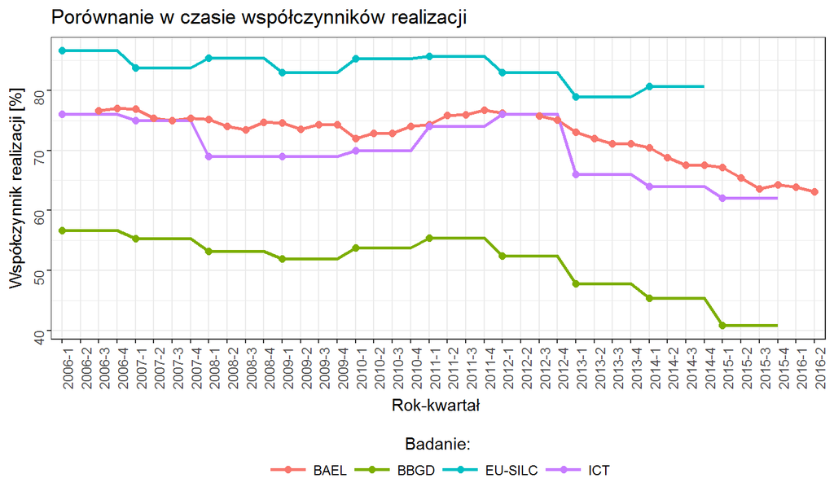

**Wskaźnik realizacji** - udział gospodarstw domowych, które zostały przebadane i ukończyły badanie spośród wszystkich wylosowanych gospodarstw domowych kwalifikujących się do uczestniczenia w badaniu

## Braki odpowiedzi w przekrojach

| Nazwa | BBGD 2006-12 | BBGD 2013-15 | EU-SILC | BAEL | ICT |
| --- | --- | --- | --- | --- | --- |
| wskaźnik realizacji |  | TAK | TAK | TAK | TAK |
| wskaźnik braków odpowiedzi | TAK |  | TAK |  |  |
| wskaźnik częściowego braku odpowiedzi | TAK | TAK | TAK |  |  |
| wskaźnik całkowitego braku odpowiedzi | TAK |  | TAK |  |  |
| próba podstawowowa/rezerwowa |  | TAK |  |  |  |
| województwa |  | TAK |  | TAK |  |
| klasy miejscowości |  | TAK |  | TAK |  |
| kwartały | TAK |  |  | TAK |  |
| który raz w badaniu | TAK | TAK |  |  |  |
| grupy społeczno-ekonomiczne | TAK |  |  |  |  |
| przyczyny nieuczestniczenia | TAK | TAK | TAK |  |  |
| wielkość gospodarstwa domowego | TAK |  |  |  |  |
| wskaźniki dla osób indywidualnych |  |  | TAK |  | TAK |
| Regiony |  |  |  |  |  |
| Powiaty |  |  |  |  |  |

## Przekroje braków odpowiedzi, a przekroje szacunków

Badanie Budżetów Gospodarstw Domowych 2013-2015

| Nazwa | Braki odpowiedzi | Szacunki |
| --- | --- | --- |
| próba podstawowa/rezerwowa | TAK |  |
| województwa | TAK | TAK |
| klasy miejscowości | TAK | TAK |
| który raz w badaniu | TAK |  |
| grupy społeczno-ekonomiczne |  | TAK |
| przyczyny nieuczestniczenia | TAK |  |
| kwantyle dochodu |  | TAK |
| typ biologiczny |  | TAK |
| wykształcenie |  | TAK |
| rodzaje budynków |  | TAK |

Przykłady

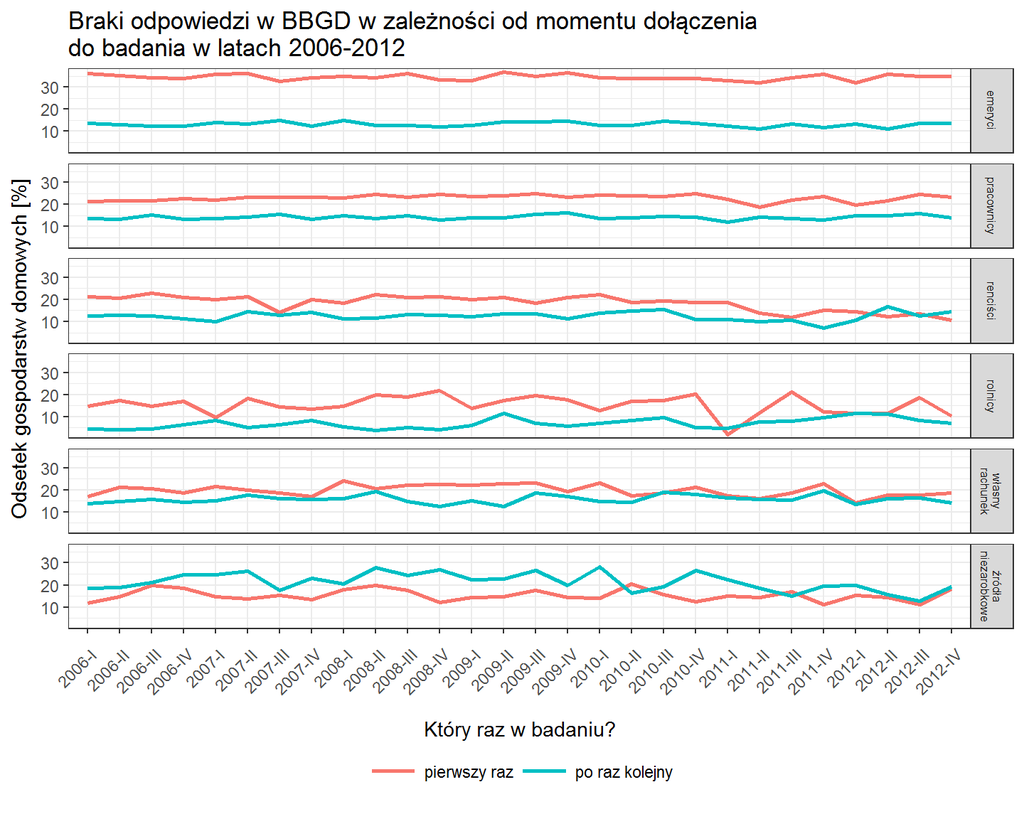

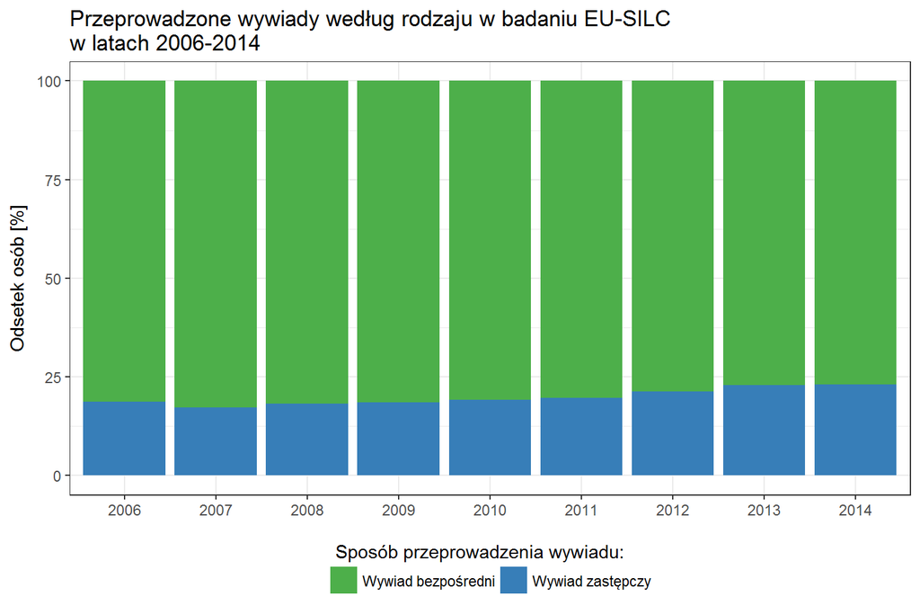

**Wywiad bezpośredni** - wywiad udzielany przez osobę, której dotyczy badanie

**Wywiad zastępczy** - wywiad udzielany przez osobę 'trzecią', która jest w stanie udzielić rzetelnych informacji za osobę której badanie dotyczy

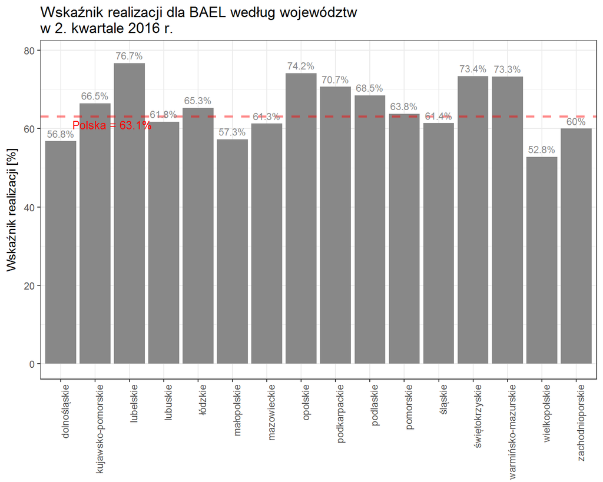

[figure not shown]

## Kwartyle wskaźników realizacji

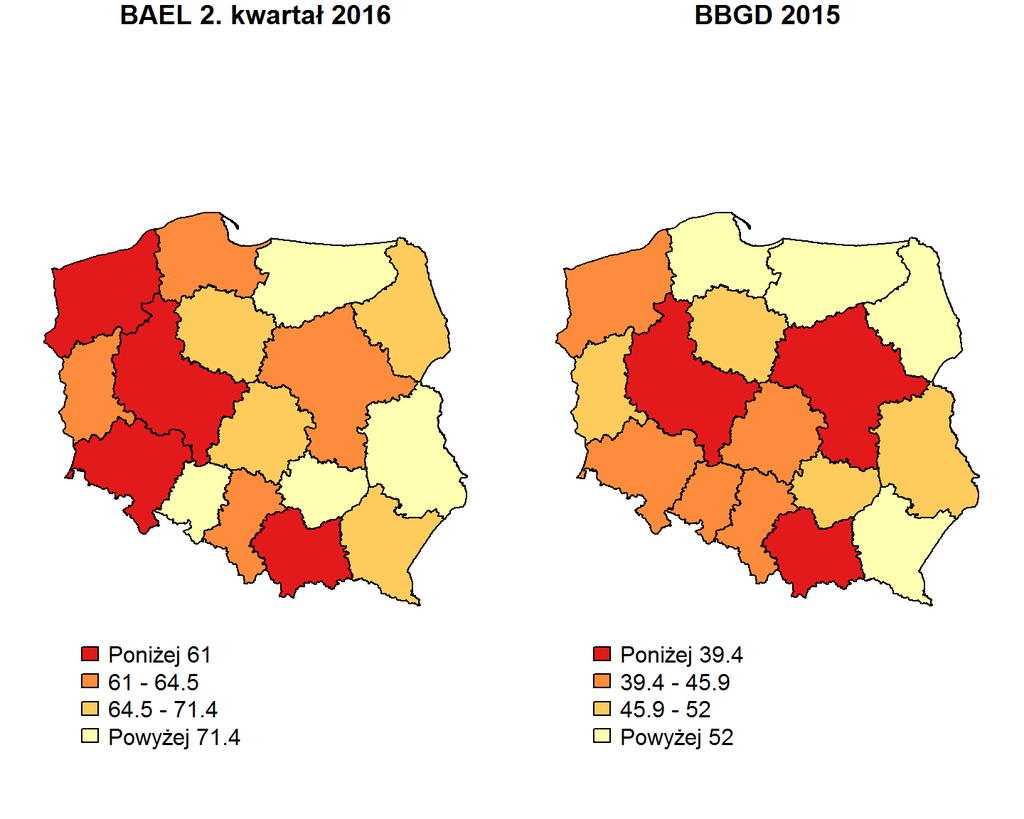

## Wskaźniki realizacji według klas miejscowości

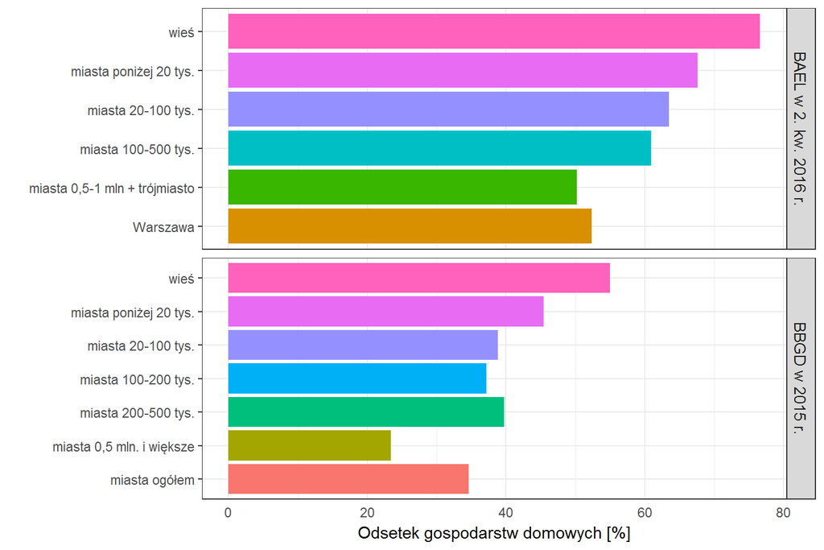

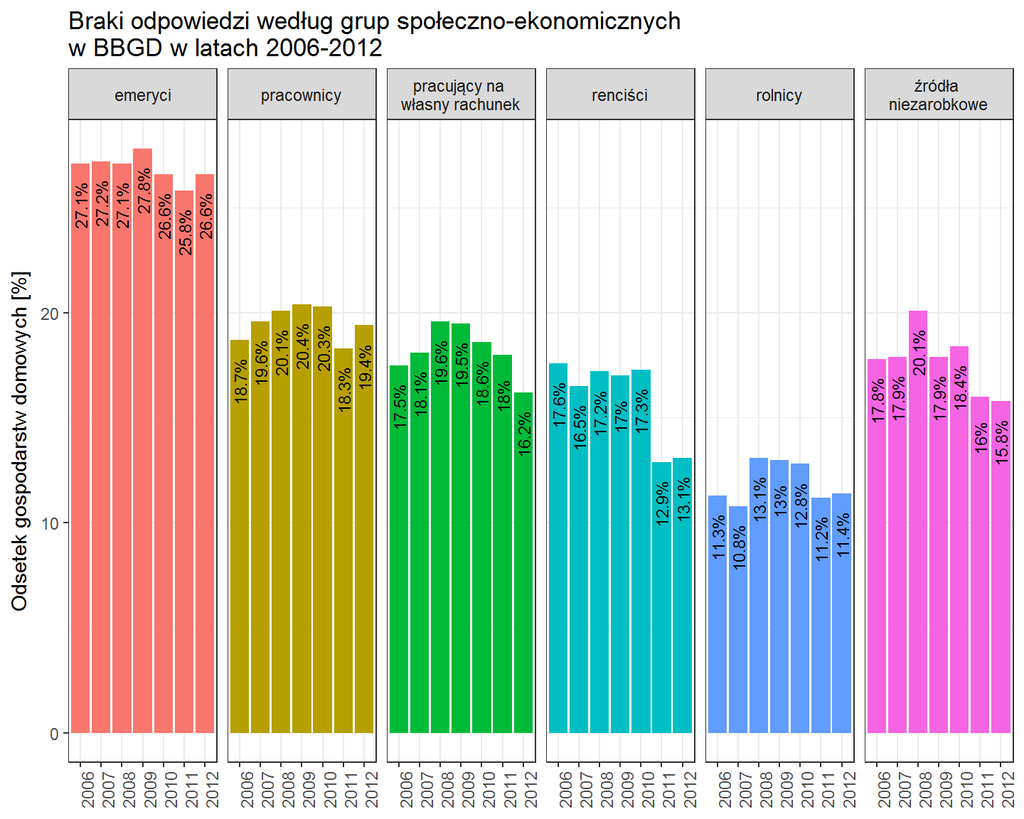

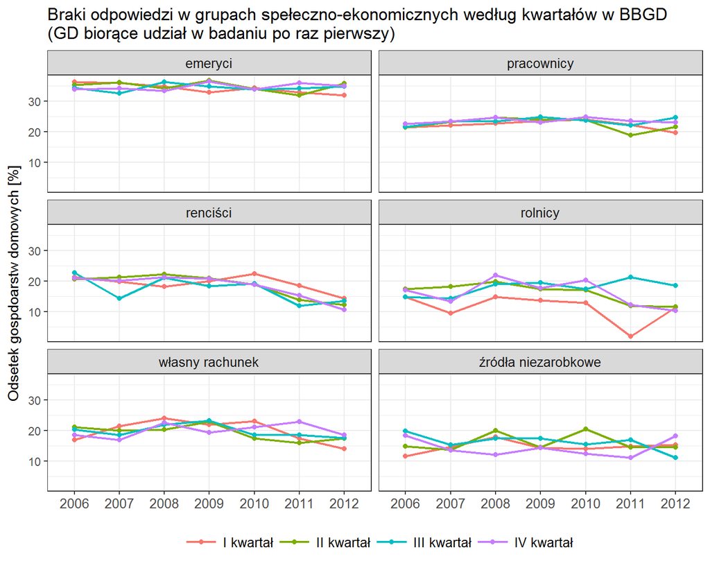

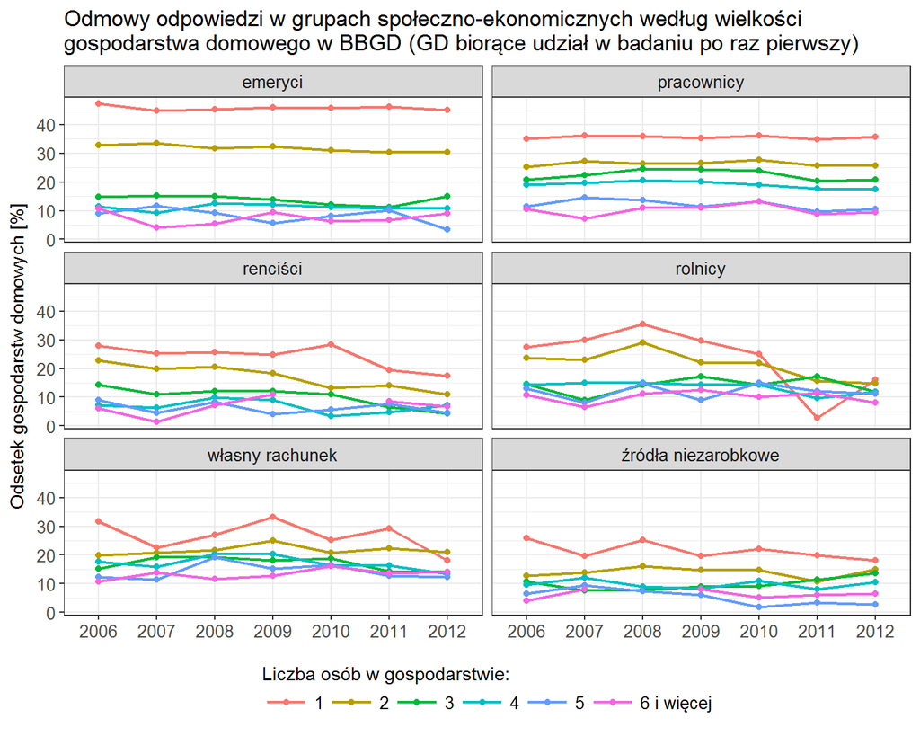

## Podsumowanie

1. Braki odpowiedzi są istotnym czynnikiem mogącym wpłynąć na wyniki analiz, raportow itp.
2. Informacje na temat braków odpowiedzi w badaniu powinny być jednymi z kluczowych danych zawartych w raporcie
3. Każde z analizowanych badań posiada informacje na temat braków danych
4. Badania charakteryzują się zróżnicowaną tematyką i sposobem organizacji, co determinuje zakres podawanych informacji, w tym tych o brakach odpowiedzi
5. W poszczególnych badaniach informacje te są zróżnicowane pod względem formy, obszerności oraz szczegółowości podawanych treści
6. Istnieje dość silna korelacja między wskaźnikami realizacji analizowanych badań
7. Na podstawie analizy zgromadzonych danych i materiałów można określić pewne wzory (prawidłowości) w występowaniu braków odpowiedzi w różnych przekrojach

## Rekomendacje

1. Zdefiniowanie pojęcia 'brak odpowiedzi'
2. Wypracowanie jednolitego nazewnictwa (wskaźnik realizacji, współczynnik realizacji, wskaźnik kopletności)
3. Ujednolicenie przekrojów dla jakich podawane są informacje na temat braków odpowiedzi - umożliwienie porównania między badaniami
4. Rozszerzenie przekrojów o np. regiony, podregiony, powiaty
5. Dostosowanie przekrojów dla braków danych i szacunków (na ile to możliwe)
6. Podawanie danych na temat braków odpowiedzi dla poziomu całego kraju w przekrojach 'nieterytorialnych' (taka sytuacja nie zawsze ma miejsce)
7. Zachowanie ciągłości podawanych informacji o brakach odpowiedzi w ramach badania - dodawanie nowych obszarów informacyjnych zamiast ich zastępowania (przykład BBGD)

## Literatura

1. Publikacje raportów z badania *Budżety Gospodarstw Domowych* za lata 2006-2015
2. Publikacje raportów z badania *Dochody i Warunki życia Ludności Polski (raport z badania EU-SILC* za lata 2006-2014)
3. Publikacje raportów z badania *Społeczeństwo Informacyjne w Polsce. Wyniki badań statystycznych* z lat 2006-2015
4. Publikacje badania *Aktywność Ekonomiczna Ludności Polski* za okres od 1 kwartału 2001 r. do 2 kwartału 2016 r.
5. Szymkowiak, M., 2009, *Estymatory kalibracyjne w badaniu Budżetów Gospodarstw Domowych*, Poznań, s. 9-12
6. *Standard Definitions. Final Dispositions of Case Codes and Outcome Rates for Surveys*, 2016, The American Association for Public Opinion Reaserch, s. 23-27, http://www.aapor.org/AAPOR_Main/media/publications/Standard-Definitions20169theditionfinal.pdf